# Interrogating Independently Compiled Police Shooting Data from 2000 to 2016

William M.

January 6, 2018

# Interrogating Independently Compiled Police Shooting Data from 2000 to 2016

## Introduction

Using a publicly available data set compiling information drawn from the news coverage of police fatalities in the United states from 2000 to 2016, we hope to gain some unique insights into the phenomenon.

Source: https://data.world/awram/us-police-involved-fatalities

## The Structure of the Data Set

The compiled data has variables representing the major circumstances of interest in a case of a police-perpetrated fatality:  
* Demographic Information for the victim  
+Name, Age, Gender, Race  
* Fatality location  
+Date, City, State  
* Details of the Encounter  
+The manner of death, whether or not the victim was armed (and if so, with what),  
+whether or not the victim was identified to have a mental illness, whether or not the victim was fleeing

The entire data set contains 12,491 events from the years 2000 to 2016.

## Armed Encounters with the Police

An obvious question to be asked given the data on hand is what portion of these police encounters resulting in a civilian fatality were the events of an armed (and potentially threatening) civilian suspect.  
While every fatal encounter should considered individually, we can reasonably say that a killing of an unarmed civilian is an undo use of force whereas a killing of an armed civilian is more likely to be necessary act of self-defense on the part of the responding police officer.  
We aggregate the data set by State and Year finding the fraction of fatalities of civilians where the civilian in question was armed*.  
The plot is shown with an “loess” line (local polynomial regression) summarizing the general trend for all ten states over the time period.

*Note: the list of weapons wielded by civilians in theses encounters is extensive and ranges from “Guns” and “Knives” to “Screwdriver” and “Metal Rake”. We will not differentiate between them at this point.

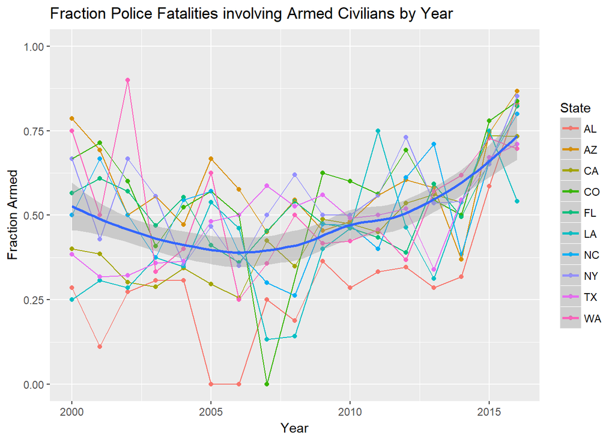

```r
Police_Fatalities$Year<-year(as.Date(Police_Fatalities$Date, "%m/%d/%Y"))
Police_Fatalities_Armed<-aggregate(Armed~State+Year, Police_Fatalities, FUN=function(a) sum(!is.na(a))/length(a), na.action=NULL)

#Order the states by total number of fatalities over entire period
numb_fatal<-aggregate(Armed~State, Police_Fatalities, FUN=length, na.action=NULL)
numb_fatal<-numb_fatal[order(-numb_fatal$Armed),]

#Plot the top ten states with the highest number of fatalities
ggplot(Police_Fatalities_Armed[Police_Fatalities_Armed$State %in% numb_fatal[1:10,1],], aes(x=Year, y=Armed, colour=State, ymin=0, ymax=1))+geom_point()+geom_line()+stat_smooth(aes(group=1), method= "loess")+ggtitle("Fraction Police Fatalities involving Armed Civilians by Year")+ylab("Fraction Armed")
```

## Police Responses

Below is a table tabulating the manner of death of each civilian in this data set with the weapon they were reported to have been carrying. This gives us a concise picture of the responses to threatening situations that police officers have made in the broad context of this study.  
The table is orderd by total frequency of fatal force applied per weapon and the twenty most frequently involved weapons are shown.

```r
table_mannerdeath<-table(Police_Fatalities$Manner_of_death, Police_Fatalities$Armed)
table_mannerdeath<-table_mannerdeath[,order(-colSums(table_mannerdeath))]
kable(table_mannerdeath[,1:10])
```

|  | Gun | Knife | Unarmed | Vehicle | Toy Weapon | Toy weapon | Machete | Unknown Weapon | Sword | Box Cutter |
| --- | --- | --- | --- | --- | --- | --- | --- | --- | --- | --- |
| Other | 2 | 4 | 1 | 0 | 0 | 0 | 0 | 0 | 0 | 0 |
| Shot | 4633 | 1301 | 357 | 107 | 68 | 29 | 13 | 14 | 8 | 3 |
| Shot and Tasered | 16 | 41 | 25 | 4 | 1 | 0 | 3 | 1 | 0 | 4 |
| Tasered | 52 | 15 | 17 | 0 | 0 | 0 | 0 | 0 | 0 | 0 |

```r
kable(table_mannerdeath[,11:20])
```

|  | Hammer | Axe | Baseball Bat | Tasered | Hatchet | Metal Pipe | Crossbow | Gun And Knife | Guns And Explosives | Screwdriver |
| --- | --- | --- | --- | --- | --- | --- | --- | --- | --- | --- |
| Other | 0 | 0 | 0 | 0 | 0 | 0 | 0 | 0 | 0 | 0 |
| Shot | 5 | 6 | 6 | 3 | 5 | 3 | 3 | 3 | 3 | 1 |
| Shot and Tasered | 2 | 0 | 0 | 3 | 0 | 2 | 0 | 0 | 0 | 2 |
| Tasered | 0 | 0 | 0 | 0 | 0 | 0 | 0 | 0 | 0 | 0 |

## Race and Lethal Force

The relationships between race and applied police force have been rigorously studied. One question that can be investigated using this data set is whether or not a fleeing civilian is more or less likely to be shot given their race. The assumption is that a civilian in the act of fleeing poses less of an immediate risk to the life of the police officer involved. While this is not immediately indicative of broader trends in race-based police violence, the answer may still be illuminating.  
We tabulate the total number of police fatalities in this data set by indicated race and whether or not they were known to be fleeing. NA values were automatically omitted.

```r
table_flee<-table(Police_Fatalities$Flee, Police_Fatalities$Race)
kable(table_flee)
```

|  | Asian | Black | Hispanic | Native | Other | White |
| --- | --- | --- | --- | --- | --- | --- |
| FALSE | 170 | 2371 | 1683 | 123 | 48 | 3609 |
| TRUE | 3 | 165 | 101 | 7 | 0 | 246 |

```r
#Chi-Squared Test of Independence
chisq.test(table_flee[,c(2, 3, 6)])
```

```
##
##  Pearson's Chi-squared test
##
## data:  table_flee[, c(2, 3, 6)]
## X-squared = 1.4473, df = 2, p-value = 0.485
```

## Conclusions

### Technical Note

$$P(was \ fleeing | was \ shot) = \frac{P(was \ fleeing)P(was \ shot | was \ fleeing)}{P(was \ shot)}$$
However, this relation would require estimates for the global fractions of all civilian-police encounters that involved a fleeing civilian (P(was fleeing)) or fatality (P(was shot)). This is beyond the scope or capabilites of this study.